# Thesis Data

Rebecca

4/2/2021

# Motivation

This analysis is intended to answer: How does cell size (length, width, volume) change in response to increased dissolved organic carbon (DOC) in the water column? This study specifically examines the feasibility of using farmed coral in a laboratory setting to model the DDAM Hypothesis.

# Setup and File Import

## Load data

```r
meta <- read.csv("~/Desktop/Liss/Data/Metadata.tsv", header = TRUE, sep = "\t", na.strings="")

MIC_118 <- read.csv("~/Desktop/Liss/Data/MIC_118.tsv", header = TRUE, sep = "\t", na.strings="")

MIC_25 <- read.csv("~/Desktop/Liss/Data/MIC_25.tsv", header = TRUE, sep = "\t", na.strings="")

MIC_44 <- read.csv("~/Desktop/Liss/Data/MIC_44.tsv", header = TRUE, sep = "\t", na.strings="")

MIC_47 <- read.csv("~/Desktop/Liss/Data/MIC_47.tsv", header = TRUE, sep = "\t", na.strings="")


MIC_53 <- read.csv("~/Desktop/Liss/Data/MIC_53.tsv", header = TRUE, sep = "\t", na.strings="")

MIC_69 <- read.csv("~/Desktop/Liss/Data/MIC_69.tsv", header = TRUE, sep = "\t", na.strings="")

MIC_81 <- read.csv("~/Desktop/Liss/Data/MIC_81.tsv", header = TRUE, sep = "\t", na.strings="")

MIC_125 <- read.csv("~/Desktop/Liss/Data/MIC_125.tsv", header = TRUE, sep = "\t", na.strings="")

MIC_178 <- read.csv("~/Desktop/Liss/Data/MIC_178.tsv", header = TRUE, sep = "\t", na.strings="")

MIC_193 <- read.csv("~/Desktop/Liss/Data/MIC_193.tsv", header = TRUE, sep = "\t", na.strings="")


MIC_107 <- read.csv("~/Desktop/Liss/Data/MIC_107.tsv", header = TRUE, sep = "\t", na.strings="")

MIC_97 <- read.csv("~/Desktop/Liss/Data/MIC_97.tsv", header = TRUE, sep = "\t", na.strings="")

MIC_212 <- read.csv("~/Desktop/Liss/Data/MIC_212.tsv", header = TRUE, sep = "\t", na.strings="")

MIC_161 <- read.csv("~/Desktop/Liss/Data/MIC_161.tsv", header = TRUE, sep = "\t", na.strings="")

MIC_203 <- read.csv("~/Desktop/Liss/Data/MIC_203.tsv", header = TRUE, sep = "\t", na.strings="")

MIC_242 <- read.csv("~/Desktop/Liss/Data/MIC_242.tsv", header = TRUE, sep = "\t", na.strings="")

MIC_273 <- read.csv("~/Desktop/Liss/Data/MIC_273.tsv", header = TRUE, sep = "\t", na.strings="")

MIC_262 <- read.csv("~/Desktop/Liss/Data/MIC_262.tsv", header = TRUE, sep = "\t", na.strings="")

MIC_252 <- read.csv("~/Desktop/Liss/Data/MIC_252.tsv", header = TRUE, sep = "\t", na.strings="")


FVM_252 <- read.csv("~/Desktop/Liss/Data/FVM_252.tsv", header = TRUE, sep = "\t", na.strings="")

meta <- read.csv("~/Desktop/Liss/Data/Metadata.tsv", header = TRUE, sep = "\t", na.strings="")

MIC_44['Sample_ID'] = 'MIC_044'
MIC_47['Sample_ID'] = 'MIC_047'
MIC_252['Sample_ID'] = 'MIC_252'
MIC_262['Sample_ID'] = 'MIC_262'
MIC_273['Sample_ID'] = 'MIC_273'
MIC_242['Sample_ID'] = 'MIC_242'
MIC_203['Sample_ID'] = 'MIC_203'
MIC_161['Sample_ID'] = 'MIC_161'
MIC_97['Sample_ID'] = 'MIC_097'
MIC_212['Sample_ID'] = 'MIC_212'
MIC_107['Sample_ID'] = 'MIC_107'
MIC_118['Sample_ID'] = 'MIC_118'
MIC_125['Sample_ID'] = 'MIC_125'
MIC_178['Sample_ID'] = 'MIC_178'
MIC_193['Sample_ID'] = 'MIC_193'
MIC_69['Sample_ID'] = 'MIC_069'
MIC_81['Sample_ID'] = 'MIC_081'
MIC_25['Sample_ID'] = 'MIC_025'
MIC_53['Sample_ID'] = 'MIC_053'
FVM_252['Sample_ID'] = 'FVM_252'

Full_Table<-rbind(MIC_107,MIC_252,MIC_262,FVM_252,MIC_273,MIC_242,MIC_203,MIC_161,MIC_212,MIC_107,MIC_193,MIC_178,MIC_125,MIC_81,MIC_69,MIC_53,MIC_44,MIC_47,MIC_25,MIC_118)
#dim(Full_Table)

Full_merge<-inner_join(meta, Full_Table, by = "Sample_ID")

#Full_Merge_Melt<-melt(data=Full_merge, id.vars=c("Sample_ID", "Timepoint",  "DOC_Treatment"))
```

I noticed that there were some negative volume calculations. I suspected it may be due to the `Length-Width` component of the volume formula and wondered if the longest measured edge was sometimes reported as the width term. Indeed, that was sometimes the case. So I compared the length and width columns and took the largest value as a new column `Length_long` and the smaller of the two values as `Width_short`. From here I recalculated the volume formula in the column `Volume_r`. That is what should be used for Volume throughout.

I also wanted to create a numerical representation of the DOC_Treatment, e.g., `DOC_1` is called `1`.

```r
# Fixing the length and width values
Full_merge$Length_long<-pmax(Full_merge$Length, Full_merge$Width)
Full_merge$Width_short<-pmin(Full_merge$Length, Full_merge$Width)
Full_merge$Volume_r = pi/4*(Full_merge$Width_short^2)*(Full_merge$Length_long-Full_merge$Width_short/3)

# Creating the new column with the numerical representation of DOC Treatment and then for Timepoint too
Full_merge<-Full_merge %>%
  mutate(DOC_num = case_when(
    endsWith(DOC_Treatment, "0") ~ "0",
    endsWith(DOC_Treatment, "1") ~ "1",
    endsWith(DOC_Treatment, "2") ~ "2",
    endsWith(DOC_Treatment, "3") ~ "3",
    TRUE                      ~ NA_character_
  ))

Full_merge$DOC_num <- as.numeric(Full_merge$DOC_num)

Full_merge<-Full_merge %>%
  mutate(Time_num = case_when(
    endsWith(Timepoint, "0") ~ "0",
    endsWith(Timepoint, "1") ~ "1",
    endsWith(Timepoint, "2") ~ "2",
    endsWith(Timepoint, "3") ~ "3",
    endsWith(Timepoint, "4") ~ "4",
    TRUE                      ~ NA_character_
  ))

Full_merge$Time_num <- as.numeric(Full_merge$Time_num)
```

# Plots

## Length and Width Analysis

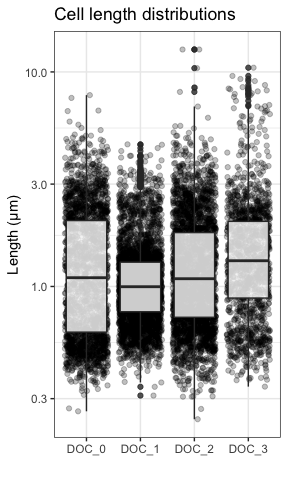

```r
ggplot(data = Full_merge, mapping=aes(x = DOC_Treatment, y = Length_long)) +
  geom_jitter(alpha = 0.25)+
  geom_boxplot(alpha=0.8) +
  scale_y_continuous(trans = 'log10')+
  labs(x = "", y = "Length (µm)")+
  ggtitle("Cell length distributions") +
  theme_bw()
```

```r
Full_merge %>%
    group_by(DOC_Treatment) %>%
    summarise(Median_Length_um = median(Length_long), Min_Length_um= min(Length_long),  Max_Length_um= max(Length_long))
```

```
## # A tibble: 4 x 4
##   DOC_Treatment Median_Length_um Min_Length_um Max_Length_um
##   <chr>                    <dbl>         <dbl>         <dbl>
## 1 DOC_0                    1.10          0.262          7.80
## 2 DOC_1                    0.997         0.310          4.60
## 3 DOC_2                    1.09          0.241         12.7
## 4 DOC_3                    1.32          0.341         10.5
```

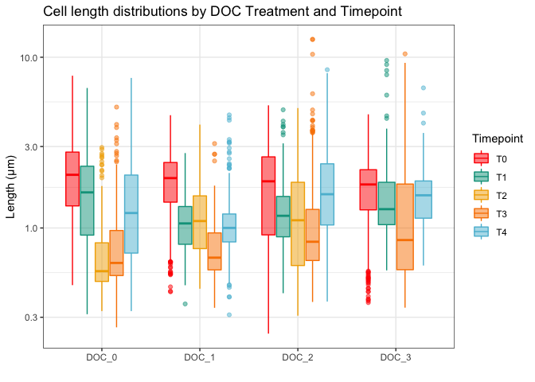

```r
ggplot(data = Full_merge, mapping=aes(x = DOC_Treatment, y = Length_long, fill=Timepoint, color =Timepoint)) +
  #geom_jitter(alpha = 0.55, aes(color=Timepoint))+
  geom_boxplot(alpha=0.5) +
  scale_fill_manual(values = wes_palette("Darjeeling1"))+
  scale_color_manual(values = wes_palette("Darjeeling1"))+
  scale_y_continuous(trans = 'log10')+
  labs(x = "", y = "Length (µm)")+
  ggtitle("Cell length distributions by DOC Treatment and Timepoint") +
  theme_bw()
```

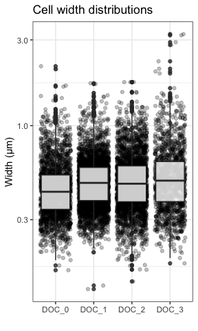

```r
ggplot(data = Full_merge, mapping=aes(x = DOC_Treatment, y = Width_short)) +
  geom_jitter(alpha = 0.25)+
  geom_boxplot(alpha=0.8) +
  scale_y_continuous(trans = 'log10')+
  labs(x = "", y = "Width (µm)")+
  ggtitle("Cell width distributions") +
  theme_bw()
```

```r
Full_merge %>%
    group_by(DOC_Treatment) %>%
    summarise(Median_Width_um = median(Width_short), Min_Width_um= min(Width_short),  Max_Width_um= max(Width_short))
```

```
## # A tibble: 4 x 4
##   DOC_Treatment Median_Width_um Min_Width_um Max_Width_um
##   <chr>                   <dbl>        <dbl>        <dbl>
## 1 DOC_0                   0.429        0.157         2.14
## 2 DOC_1                   0.481        0.123         1.72
## 3 DOC_2                   0.476        0.136         1.75
## 4 DOC_3                   0.495        0.171         3.23
```

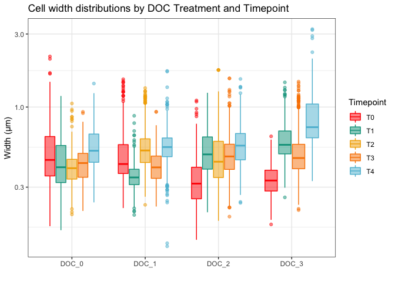

```r
ggplot(data = Full_merge, mapping=aes(x = DOC_Treatment, y = Width_short, fill = Timepoint, color =Timepoint)) +
  geom_boxplot(alpha=0.5) +
  scale_y_continuous(trans = 'log10')+
  scale_fill_manual(values = wes_palette("Darjeeling1"))+
  scale_color_manual(values = wes_palette("Darjeeling1"))+
  labs(x = "", y = "Width (µm)")+
  ggtitle("Cell width distributions by DOC Treatment and Timepoint") +
  theme_bw()
```

## Volume Analysis

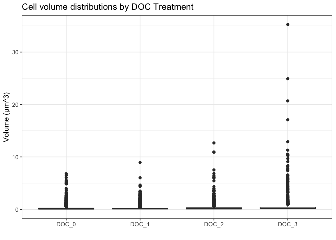

```r
ggplot(data = Full_merge, mapping=aes(x = DOC_Treatment, y = Volume_r)) +
  geom_boxplot() +
  #scale_y_continuous(trans = 'log10')+
  labs(x = "", y = "Volume (µm^3)")+
  ggtitle("Cell volume distributions by DOC Treatment") +
theme_bw()
```

If the ANOVA residuals are normally distributed, we know the data within each level of the grouping factor is too. So first we create the ANOVA model to determine whether the DOC treatments significantly differ in cell volume. We use two ANOVA methods that perform identical functions, but give slightly different default outputs, which can be handy later. We run a Tukey HSD test for multiple comparisons in the ANOVA model.

```r
#ANOVA test 1
DOC_Volume_lm.model <- lm(data=Full_merge, Volume_r ~ DOC_Treatment)
summary(DOC_Volume_lm.model)
```

```
##
## Call:
## lm(formula = Volume_r ~ DOC_Treatment, data = Full_merge)
##
## Residuals:
##    Min     1Q Median     3Q    Max
## -0.576 -0.218 -0.140 -0.021 34.659
##
## Coefficients:
##                    Estimate Std. Error t value Pr(>|t|)
## (Intercept)         0.28507    0.01746  16.328   <2e-16 ***
## DOC_TreatmentDOC_1 -0.05201    0.02235  -2.327    0.020 *
## DOC_TreatmentDOC_2  0.03141    0.02315   1.357    0.175
## DOC_TreatmentDOC_3  0.30791    0.02772  11.109   <2e-16 ***
## ---
## Signif. codes:  0 '***' 0.001 '**' 0.01 '*' 0.05 '.' 0.1 ' ' 1
##
## Residual standard error: 0.8313 on 10295 degrees of freedom
## Multiple R-squared:  0.0194, Adjusted R-squared:  0.01911
## F-statistic: 67.89 on 3 and 10295 DF,  p-value: < 2.2e-16
```

```r
#ANOVA test 2
DOC_Volume_aov.model <- aov(data=Full_merge, Volume_r ~ DOC_Treatment)
summary(DOC_Volume_aov.model)
```

```
##                  Df Sum Sq Mean Sq F value Pr(>F)
## DOC_Treatment     3    141   46.91   67.89 <2e-16 ***
## Residuals     10295   7114    0.69
## ---
## Signif. codes:  0 '***' 0.001 '**' 0.01 '*' 0.05 '.' 0.1 ' ' 1
```

But before continuing with the ANOVA model evaluation, we need to confirm the follow assumptions of the ANOVA test are met (from https://dzchilds.github.io/stats-for-bio/data-transformations.html): **Independence.** The experimental units of the data must be independent. **Measurement scale.** The response variable is measured on an interval or ratio scale. Here, this is the volume data, which is on an interval scale. **Normality.** The residuals are normally distributed in each level of the grouping factor. **Equal variance.** The variance in each level of the grouping factor is the same.

### Testing for normality and equal variance

We check the normality of the data with a histogram. Next to it we plot the Normal QQ and scale-location plots of the ANOVA mode to assess the normality and equal variance assumptions of the ANOVA model.

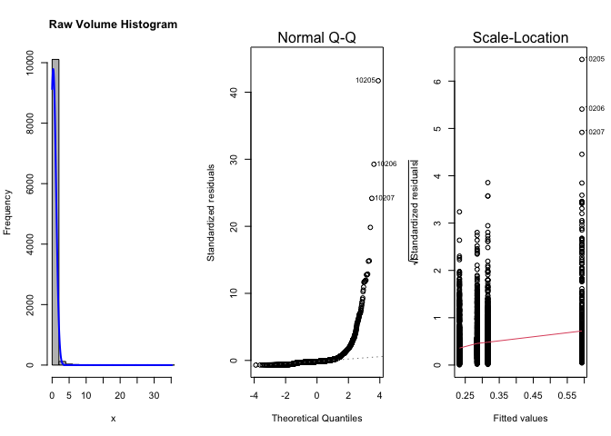

```r
par(mfrow = c(1, 3)) # combine plots
plotNormalHistogram(Full_merge$Volume_r)
title("Raw Volume Histogram")
plot(DOC_Volume_lm.model, which = 2)
plot(DOC_Volume_lm.model, which = 3)
```

The data in the histogram does not fit a normal distribution (plot on left).

The Q-Q plot indicates heavily right-skewed residuals in the upward curvature of the line (middle plot).

As for the assumptin of equal variance, in the initial box plots we made above, it does look like the data from the different DOC treatments have different scatter. The Scale-location plot (last plot) indicates that variance increases with fitted values.

All three tests indicate that the volume data do not fit a normal distribution. We try both a squart root transformation and log transformation below.You can read more about transformations here: https://rcompanion.org/handbook/I_12.html and https://dzchilds.github.io/stats-for-bio/data-transformations.html #### Square root transformation of volume data

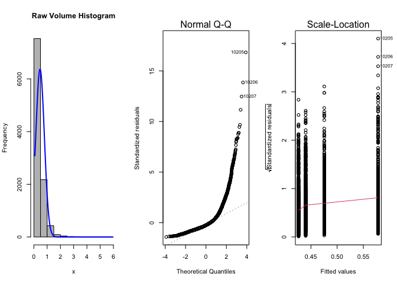

```r
#ANOVA test 1
DOC_Volume_sqrt_lm.model <- lm(data=Full_merge, sqrt(Volume_r) ~ DOC_Treatment)

par(mfrow = c(1, 3)) # combine plots
plotNormalHistogram(sqrt(Full_merge$Volume_r))
title("Raw Volume Histogram")
plot(DOC_Volume_sqrt_lm.model, which = 2)
plot(DOC_Volume_sqrt_lm.model, which = 3)
```

#### Log transformation of volume data

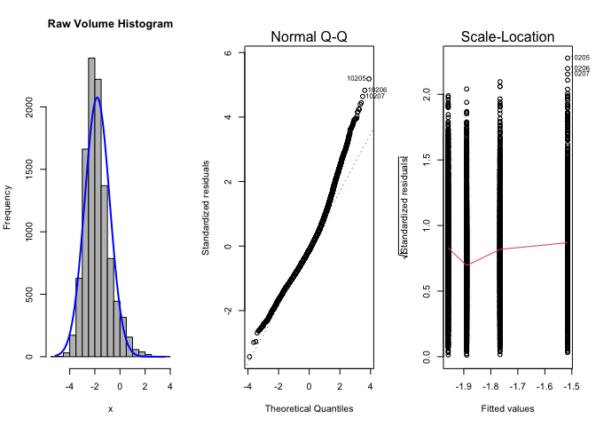

```r
#ANOVA test 1
DOC_Volume_log_lm.model <- lm(data=Full_merge, log(Volume_r) ~ DOC_Treatment)

par(mfrow = c(1, 3)) # combine plots
plotNormalHistogram(log(Full_merge$Volume_r))
title("Raw Volume Histogram")
plot(DOC_Volume_log_lm.model, which = 2)
plot(DOC_Volume_log_lm.model, which = 3)
```

Log brings the data certainly bring the data to better fit the normal distribution (at least by eye). The residuals are still slightly right-skewed, but not nearly as heavily as the untransformed data. The variance looks much more equal. These are likley only minor violations of ANOVA assumptions and most likley won’t strongly influence the ANOVA model predictions.

Then we repeat the ANOVA test with our now normally distributed log-transformed volume data.

```r
#ANOVA test 1
DOC_Volume_log_lm.model <- lm(data=Full_merge, Volume_r_log ~ DOC_Treatment)
```

[output not shown]

```r
summary(DOC_Volume_log_lm.model)
```

```
##
## Call:
## lm(formula = log(Volume_r) ~ DOC_Treatment, data = Full_merge)
##
## Residuals:
##     Min      1Q  Median      3Q     Max
## -3.3613 -0.6658 -0.1207  0.5078  5.0781
##
## Coefficients:
##                    Estimate Std. Error t value Pr(>|t|)
## (Intercept)        -1.95772    0.02058 -95.109  < 2e-16 ***
## DOC_TreatmentDOC_1  0.06831    0.02635   2.593  0.00954 **
## DOC_TreatmentDOC_2  0.19192    0.02729   7.032 2.17e-12 ***
## DOC_TreatmentDOC_3  0.44211    0.03268  13.529  < 2e-16 ***
## ---
## Signif. codes:  0 '***' 0.001 '**' 0.01 '*' 0.05 '.' 0.1 ' ' 1
##
## Residual standard error: 0.9801 on 10295 degrees of freedom
## Multiple R-squared:  0.02048,    Adjusted R-squared:  0.02019
## F-statistic: 71.74 on 3 and 10295 DF,  p-value: < 2.2e-16
```

```r
#ANOVA test 2
DOC_Volume_log_aov.model <- aov(data=Full_merge, Volume_r_log ~ DOC_Treatment)
```

[output not shown]

```r
summary(DOC_Volume_log_aov.model)
```

[output not shown]

```r
TukeyHSD(DOC_Volume_log_aov.model)
```

[output not shown]

```r
# Tukey plot :
plot(TukeyHSD(DOC_Volume_log_aov.model), las=1, col="brown")
```

[output not shown]

But when smaple sizes are large (like these), even small effects can lead to low p-values), so we should evaluate the effect size. The sample R-squared can be used, which measures the proportion of explained variability in the response (here, cell volume) accounted for by the independent variable (here, DOC_treatment) and estimates some “true” proportion theta. For large samples, even if R-squared is close to zero, the F-test will provide a small p-value.

We next wanted a quick peak at how these trends behaved through time. We will extend our statistical analyses to the time series when we have the complete dataset.

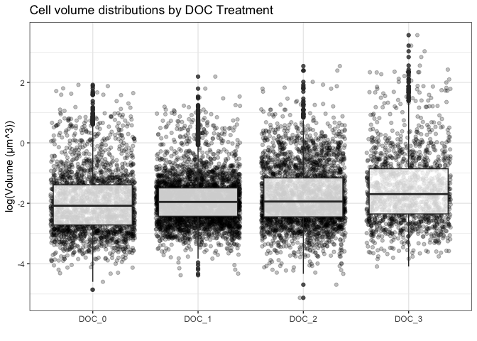

```r
Full_merge$Volume_r_log <- log(Full_merge$Volume_r)

ggplot(data = Full_merge, mapping=aes(x = DOC_Treatment, y = Volume_r_log)) +
  geom_jitter(alpha = 0.25)+
  geom_boxplot(alpha=0.8) +
  labs(x = "", y = "log(Volume (µm^3))")+
  ggtitle("Cell volume distributions by DOC Treatment") +
  theme_bw()
```

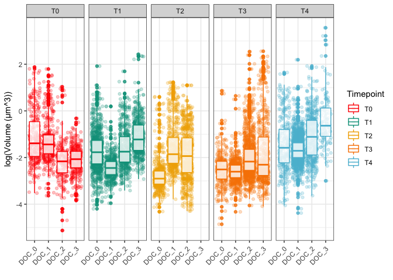

```r
Full_merge$Volume_r_log <- log(Full_merge$Volume_r)

ggplot(data = Full_merge, mapping=aes(x = DOC_Treatment, y = Volume_r_log, color = Timepoint)) +
  geom_jitter(aes(colour = Timepoint), alpha = 0.25)+
  geom_boxplot(alpha=0.8) +
  labs(x = "", y = "log(Volume (µm^3))")+
  facet_grid(~Timepoint)+
  scale_color_manual(values = wes_palette("Darjeeling1"))+
  theme_bw()+
  theme(axis.text.x = element_text(angle = 45, vjust = 0.95, hjust=1))
```

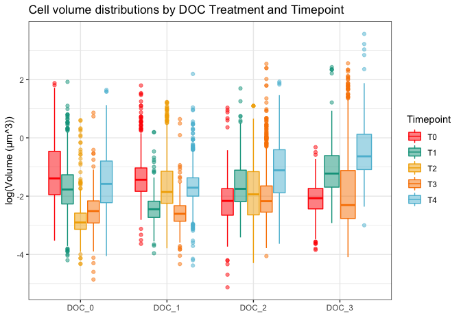

```r
Full_merge$Volume_r_log <- log(Full_merge$Volume_r)

ggplot(data = Full_merge, mapping=aes(x = DOC_Treatment, y = Volume_r_log, fill=Timepoint, color = Timepoint)) +
  #geom_jitter(alpha = 0.25)+
  geom_boxplot(alpha=0.5) +
  scale_fill_manual(values = wes_palette("Darjeeling1"))+
  scale_color_manual(values = wes_palette("Darjeeling1"))+
  labs(x = "", y = "log(Volume (µm^3))")+
  ggtitle("Cell volume distributions by DOC Treatment and Timepoint") +
  theme_bw()
```

Should there be any doubt that the lack of normality of equal variance influenced the ANOVA significance tests, we also performed the non-parametric test Kruskal Wallis that compares group means but doed not require the normality assumption to be met.

```r
DOC_Volume_kruskal.test<- kruskal.test(Volume_r ~ DOC_Treatment, data=Full_merge)
DOC_Volume_kruskal.test
```

```
##
##  Kruskal-Wallis rank sum test
##
## data:  Volume_r by DOC_Treatment
## Kruskal-Wallis chi-squared = 165.35, df = 3, p-value < 2.2e-16
```

As we expected due to the minor violations of ANOVA assumptions, this model is also significant (H statistic = 165.35; p-value = < 2.2e-16). There are no nonparametric multiple comparison tests yet written in R, so we can’t compare with a Tukey analog here.

### Linear regressions with numerical predictors

I’ve been thinking about that DOC parameter. In the ANOVA, the DOC treatments are treated as a group of four levels. But in reality, the relationships between those levels is meaningful. There is an order to them 0-3. But yet they are not truly numerical either. I see it is common practice is to treat predictors like this as continuous, which may be ok. If we do that, we can run a linear regression not with groups, but with numerical values for both Y~X. The tests to use are either Pearson (parametric test) or Spearman (non-parametric test).

#### DOC and cell volume

This can be visualized in this plot:

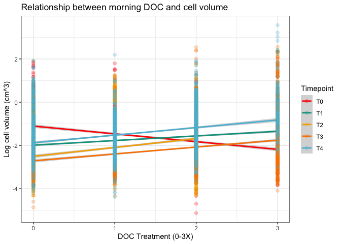

```r
# Predictor vs Criterion {ggplot2} - separate regression lines
ggplot(data = Full_merge,
       aes(x = DOC_num,
           y = Volume_r_log,
           colour=Timepoint)) +
  geom_smooth(method=lm) +
  geom_point(size = 2, alpha=0.25) +
  scale_colour_manual(values = wes_palette("Darjeeling1"))+
  ggtitle("Relationship between morning DOC and cell volume") +
  xlab("DOC Treatment (0-3X)") + ylab("Log cell volume (cm^3)")+
  theme_bw()
```

And here are the same parameters, but looking at changes in each Treatment through time.

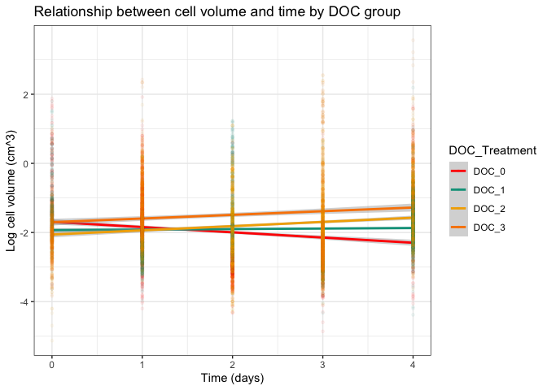

```r
# Predictor vs Criterion {ggplot2} - separate regression lines
ggplot(data = Full_merge,
       aes(x = Time_num,
           y = Volume_r_log,
           colour=DOC_Treatment)) +
  geom_smooth(method=lm) +
  geom_point(size = 1, alpha=0.05) +
  scale_colour_manual(values = wes_palette("Darjeeling1"))+
  ggtitle("Relationship between cell volume and time by DOC group") +
  xlab("Time (days)") + ylab("Log cell volume (cm^3)")+
  theme_bw()
```

Though messy, this shows that for all points after T0, there is a the positive relationship between DOC treatment and cell volume. Again, this is what would be expected in the DDAM progression.

To evaluate the significance of this trend with a Spearman rank correlation test:

```r
# Assumes both variables are normally distributed, which I would say is not true of the relative DOC values
#cor.test(~ DOC_num + Volume_r_log, method = "pearson", data = Full_merge)

# Non-parametric, so does not need normally distributed variables

# BY TIMEPOINTS
cor.test(~ DOC_num + Volume_r, method = "spearman", data = filter(Full_merge, Timepoint == "T0"))
```

```
##
##  Spearman's rank correlation rho
##
## data:  DOC_num and Volume_r
## S = 356776989, p-value < 2.2e-16
## alternative hypothesis: true rho is not equal to 0
## sample estimates:
##        rho
## -0.4335397
```

```r
cor.test(~ DOC_num + Volume_r, method = "spearman", data = filter(Full_merge, Timepoint == "T1"))
```

```
##
##  Spearman's rank correlation rho
##
## data:  DOC_num and Volume_r
## S = 1719124159, p-value < 2.2e-16
## alternative hypothesis: true rho is not equal to 0
## sample estimates:
##       rho
## 0.2425472
```

```r
cor.test(~ DOC_num + Volume_r, method = "spearman", data = filter(Full_merge, Timepoint == "T2"))
```

```
##
##  Spearman's rank correlation rho
##
## data:  DOC_num and Volume_r
## S = 536471169, p-value < 2.2e-16
## alternative hypothesis: true rho is not equal to 0
## sample estimates:
##       rho
## 0.3573896
```

```r
cor.test(~ DOC_num + Volume_r, method = "spearman", data = filter(Full_merge, Timepoint == "T3"))
```

```
##
##  Spearman's rank correlation rho
##
## data:  DOC_num and Volume_r
## S = 2204052411, p-value < 2.2e-16
## alternative hypothesis: true rho is not equal to 0
## sample estimates:
##       rho
## 0.2579149
```

```r
cor.test(~ DOC_num + Volume_r, method = "spearman", data = filter(Full_merge, Timepoint == "T4"))
```

```
##
##  Spearman's rank correlation rho
##
## data:  DOC_num and Volume_r
## S = 1.846e+09, p-value < 2.2e-16
## alternative hypothesis: true rho is not equal to 0
## sample estimates:
##       rho
## 0.2422084
```

#### Dissolved oxygen and cell volume

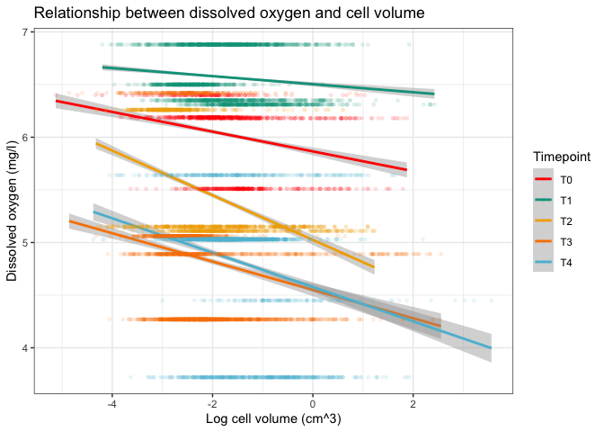

```r
ggplot(data = Full_merge,
       aes(x = Volume_r_log,
           y = DO_am,
           colour=Timepoint)) +
  geom_smooth(method=lm) +
  geom_point(size = 1, alpha = 0.1) +
  scale_color_manual(values = wes_palette("Darjeeling1"))+
  ggtitle("Relationship between dissolved oxygen and cell volume") +
  xlab("Log cell volume (cm^3)") + ylab("Dissolved oxygen (mg/l)")+
  theme_bw()
```

```r
# BY TIMEPOINTS
cor.test(~ DO_am + Volume_r, method = "spearman", data = filter(Full_merge, Timepoint == "T0"))
```

```
##
##  Spearman's rank correlation rho
##
## data:  DO_am and Volume_r
## S = 359616968, p-value < 2.2e-16
## alternative hypothesis: true rho is not equal to 0
## sample estimates:
##        rho
## -0.4449508
```

```r
cor.test(~ DO_am + Volume_r, method = "spearman", data = filter(Full_merge, Timepoint == "T1"))
```

```
##
##  Spearman's rank correlation rho
##
## data:  DO_am and Volume_r
## S = 2820100069, p-value < 2.2e-16
## alternative hypothesis: true rho is not equal to 0
## sample estimates:
##        rho
## -0.2425472
```

```r
cor.test(~ DO_am + Volume_r, method = "spearman", data = filter(Full_merge, Timepoint == "T2"))
```

```
##
##  Spearman's rank correlation rho
##
## data:  DO_am and Volume_r
## S = 1250939170, p-value < 2.2e-16
## alternative hypothesis: true rho is not equal to 0
## sample estimates:
##        rho
## -0.4984338
```

```r
cor.test(~ DO_am + Volume_r, method = "spearman", data = filter(Full_merge, Timepoint == "T3"))
```

```
##
##  Spearman's rank correlation rho
##
## data:  DO_am and Volume_r
## S = 3884460495, p-value < 2.2e-16
## alternative hypothesis: true rho is not equal to 0
## sample estimates:
##        rho
## -0.3078638
```

```r
cor.test(~ DO_am + Volume_r, method = "spearman", data = filter(Full_merge, Timepoint == "T4"))
```

```
##
##  Spearman's rank correlation rho
##
## data:  DO_am and Volume_r
## S = 2964301824, p-value < 2.2e-16
## alternative hypothesis: true rho is not equal to 0
## sample estimates:
##        rho
## -0.2168503
```

There is a significant negative correlation between morning dissolved oxygen and cell volume at all time points Spearman (p-value < 2.2e-16). Depressed dissolved oxygen values are a signed of increased heterotrophic respiration.

A negative relationship between DO and cell volumes is what we would expect if the DDAM process was induced.

#### DOC and DO

```r
cor.test(~ DOC_num + DO_am, method = "spearman", data = Full_merge)
```

```
##
##  Spearman's rank correlation rho
##
## data:  DOC_num and DO_am
## S = 2.6013e+11, p-value < 2.2e-16
## alternative hypothesis: true rho is not equal to 0
## sample estimates:
##        rho
## -0.4287454
```

This relationship can be demonstrated here:

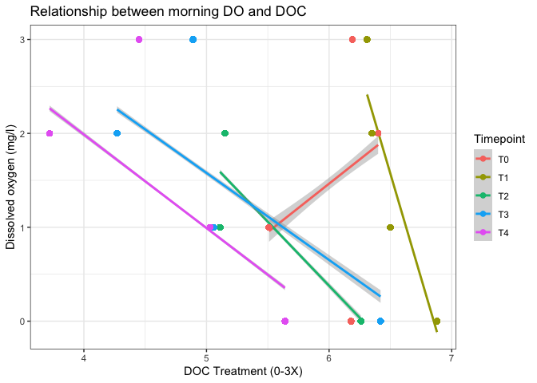

```r
# Predictor vs Criterion {ggplot2} - separate regression lines
ggplot(data = Full_merge,
       aes(x = DO_am,
           y = DOC_num,
           colour=Timepoint)) +
  geom_smooth(method=lm) +
  geom_point(size = 2) +
  ggtitle("Relationship between morning DO and DOC") +
  xlab("DOC Treatment (0-3X)") + ylab("Dissolved oxygen (mg/l)")+
  theme_bw()
```

After T0, a negative relationship expected between DOC and DO. This was expected as DOC stimulated oxygen consumption.

### One way ANCOVA with DOC and dissolved oxygen (DO)

Here we create a one-way ANCOVA by incorporating morning dissolved oxygen measurements as a covariate variable with the DOC treatment groups. Then we evaluate the behavior to determine whether we will further interpret it (spoiler, we don’t).

```r
Volume_log_DO_DOC_aov.model <- aov(Volume_r_log ~ DOC_Treatment + DO_am, data = Full_merge)
summary(Volume_log_DO_DOC_aov.model)
```

```
##                  Df Sum Sq Mean Sq F value Pr(>F)
## DOC_Treatment     3    207   68.91   72.22 <2e-16 ***
## DO_am             1     67   67.22   70.46 <2e-16 ***
## Residuals     10294   9821    0.95
## ---
## Signif. codes:  0 '***' 0.001 '**' 0.01 '*' 0.05 '.' 0.1 ' ' 1
```

```r
# Run equivalent linear model
Volume_log_DO_DOC_lm.model <- lm(Volume_r_log ~ DOC_Treatment + DO_am, data = Full_merge)
summary(Volume_log_DO_DOC_lm.model)
```

```
##
## Call:
## lm(formula = Volume_r_log ~ DOC_Treatment + DO_am, data = Full_merge)
##
## Residuals:
##     Min      1Q  Median      3Q     Max
## -3.1785 -0.6589 -0.1118  0.5081  4.9388
##
## Coefficients:
##                     Estimate Std. Error t value Pr(>|t|)
## (Intercept)        -1.192061   0.093495 -12.750   <2e-16 ***
## DOC_TreatmentDOC_1 -0.066211   0.030763  -2.152   0.0314 *
## DOC_TreatmentDOC_2  0.005591   0.035110   0.159   0.8735
## DOC_TreatmentDOC_3  0.345675   0.034536  10.009   <2e-16 ***
## DO_am              -0.119078   0.014186  -8.394   <2e-16 ***
## ---
## Signif. codes:  0 '***' 0.001 '**' 0.01 '*' 0.05 '.' 0.1 ' ' 1
##
## Residual standard error: 0.9768 on 10294 degrees of freedom
## Multiple R-squared:  0.02714,    Adjusted R-squared:  0.02676
## F-statistic: 71.78 on 4 and 10294 DF,  p-value: < 2.2e-16
```

ANCOVA makes several assumptions about the data (from https://www.datanovia.com/en/lessons/ancova-in-r/): **Linearity between the covariate and the outcome variable** at each level of the grouping variable. This can be checked by creating a grouped scatter plot of the covariate and the outcome variable. **Homogeneity of regression slopes.** The slopes of the regression lines, formed by the covariate and the outcome variable, should be the same for each group. This assumption evaluates that there is no interaction between the outcome and the covariate. The plotted regression lines by groups should be parallel. **The outcome variable should be approximately normally distributed.** This can be checked using the Shapiro-Wilk test of normality on the model residuals. **Homoscedasticity** or homogeneity of residuals variance for all groups. The residuals are assumed to have a constant variance (homoscedasticity) **No significant outliers** in the groups

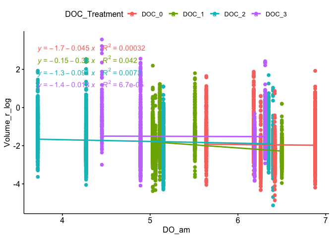

```r
ggscatter(Full_merge, x = "DO_am", y = "Volume_r_log",
  color = "DOC_Treatment", add = "reg.line"
  )+
  stat_regline_equation(
    aes(label =  paste(..eq.label.., ..rr.label.., sep = "~~~~"), color = DOC_Treatment)
    )
```

I would say this does not pass the linearity test. So we should stop here with the ANCOVA.